# Racial profiling - drug searches on foot by uniform police

Monika Sarder

2025-11-03

# Abstract

This study analyses **7,534 warrantless drug searches** conducted by **uniform, station-based officers during pedestrian encounters** in metropolitan Melbourne during **2018, 2019, 2022, and 2023**.

It focuses on people perceived by police as **White** or **African**, who together comprise over 50% of searches.

Across years, **hit rates** (contraband found) were generally lower for African-appearing individuals than for White-appearing individuals.

Exploratory checks in the appendix confirm that areas with **higher recorded drug-crime rates** tend to have **more searches per capita** and somewhat **lower evidentiary yield**, supporting the need to adjust for **station-level policing intensity** when testing for racial disparities.

**Model B**, a **multilevel logistic regression** with **random intercepts for station** (**N = 7,479 across 71 stations**), shows a comparable city-wide effect, with African-appearing individuals having a **≈30% lower odds of a hit** than White-appearing individuals (**OR = 0.73, 95% CI 0.57–0.93, p = 0.011**).

Search target’s gender and rank of officer conducting the search were not significant predictors.

While the hit-rate framework cannot infer motive, the results are **consistent with lower search thresholds being applied to African-appearing individuals** in certain operational contexts.

These findings highlight the importance of **station-level review and transparency** in Victoria Police’s stop-and-search practices.

# 1 Introduction

This analysis examines **7,534 warrantless drug searches** conducted by **uniformed officers during pedestrian encounters** in **metropolitan Melbourne** during **2018, 2019, 2022, and 2023**, involving people perceived as having *White* or *African* appearance by Victoria Police.

These encounters represent the most routine and discretionary form of public-place policing, where outcomes depend heavily on individual officer judgement rather than intelligence-led or warrant-based operations.

## 1.1 Purpose and scope

The aim is to investigate whether search outcomes indicate evidence of **racial profiling** — that is, whether people perceived as African are subjected to searches on a **lower evidentiary threshold** than people perceived as White.

This focus reflects both **data quality and historical context**. The **Haile-Michael case** and **recurring allegations of racial profiling of African-Australians** in Victoria have drawn sustained public and policy attention to policing practices affecting this group. Concentrating on this comparison allows a direct test of whether such disparities are observable in routine operational data.

The two racial appearance categories analysed — *African* and *White* — represent two of the largest and most consistently recorded groupings in the dataset, enabling robust and interpretable comparison of outcomes across time and space.

Restricting the analysis to **uniform pedestrian encounters** and **drug-related searches** further reduces confounding. These encounters occur in public settings under a single legislative authority — *section 82 of the Drugs, Poisons and Controlled Substances Act 1981 (Vic)* — which permits searches without a warrant when an officer has *reasonable grounds to suspect* drug possession.

By excluding **vehicle stops**, **warrant searches**, and **specialist or Transit Police operations**, the analysis isolates the most discretionary form of search activity. In particular, removing **Transit Police** and **Protective Services Officers (PSOs)** excludes searches around train stations and transport hubs — areas with distinct patterns of offending and demographic composition — ensuring the analysis reflects **community-based policing contexts** rather than **transport-enforcement settings**.

## 1.2 Spatial and organisational structure

A key feature of this dataset is that every search is linked to the officer’s **home police station**, enabling the use of **station-level controls** to account for local operational contexts.

There are **84 uniform stations** represented in the data, each associated with a **Police Service Area (PSA)** and nested within one or more **Local Government Areas (LGAs)** and **Victoria Police Divisions**.

Within each PSA, every uniform station maintains a **geographic response or patrol zone** that defines its core area of responsibility for first response and routine patrol. These zones are set operationally by Victoria Police’s regional commands to balance population, workload, and response times. They represent the smallest consistent unit of geographic responsibility for **general-duties (uniform) police**, excluding specialist units such as Transit Police or Highway Patrol that operate across broader areas.

Although every station has a defined response zone, **the precise patrol-zone boundaries are not publicly released**, and they do **not formally align with ABS Statistical Area Level 1 (SA1) or Level 2 (SA2)** boundaries. They are administrative rather than statistical geographies. Consequently, while **station-level controls** capture much of the spatial variation in policing practice, they cannot account for all fine-grained contextual differences (e.g., between specific neighbourhoods, streets, or hotspots within a station zone).

Because most **pedestrian searches** are carried out by officers based at their local station and operating within these response zones, the use of station as the spatial unit enables meaningful *within-context* comparisons of racial disparities without conflating them with broader geographic variation. However, some limitations remain. The dataset lacks precise spatial coordinates and complete age data, which constrains the ability to model micro-contextual factors.

Even so, conditioning on station-level variation substantially reduces **spatial confounding**, allowing comparisons to be made within consistent and operationally meaningful boundaries. This approach ensures that the analysis focuses on variation in **decision-making**, rather than differences in **deployment location**.

## 1.3 The hit-rate test framework

The analysis applies the outcomes-based or “hit-rate” test introduced by **Knowles, Persico, and Todd (2001)** and formalised by **Persico and Todd (2004)**.

In their economic model, police officers are assumed to allocate **pedestrian searches** across groups to maximise the probability of discovering contraband. If officers act without bias, equilibrium requires that the hit rates — the proportion of searches yielding contraband — are equal across racial groups. Conversely, if officers apply a lower suspicion threshold to one group (searching them more frequently or with less cause), that group will exhibit a lower hit rate, as more searches are conducted on weaker grounds.

This provides a clear behavioural test for racial bias: unequal hit rates, after accounting for legitimate contextual variation, imply that one group is being held to a different evidentiary standard. While the hit-rate approach cannot directly measure motive or intent, it captures the observable consequence of biased decision-making.

As Persico and Todd emphasise, equalised hit rates across racial groups are a necessary condition for “efficient, unbiased” policing. Persistent disparities — particularly within the same station and year — suggest that race may influence who is deemed suspicious enough to search.

### 1.3.1 Limitations and critiques

Despite its appeal, the hit-rate framework has attracted **substantial criticism** in the policing and econometric literature. Analysts including **Ridgeway and MacDonald (2010)** note that hit-rate analyses can **misattribute disparities** if underlying offence types, officer roles, or situational contexts differ systematically across racial groups. In practice, disparities in hit rates may reflect **differences in exposure, offence type, or patrol environments** rather than the discretionary threshold itself.

The RAND review further highlights a structural issue known as the **“subgroup validity problem”** (Ayres 2002): if different racial groups are subject to **pedestrian encounters** for different types of suspected offences — for instance, if one group is more often stopped for low-yield drug possession — aggregate hit rates will differ even under unbiased policing. Similarly, failing to control for **station-level variation** or **officer assignment patterns** can confound results, overstating or obscuring racial effects.

As such, the hit-rate test should be interpreted as an **indicator of potential bias**, not as a definitive measure. When combined with **station-level controls**, **fixed-effects modelling**, and **internal benchmarking** (comparing officers or stations operating in similar contexts), it remains a valuable tool for identifying areas where **discretionary decision-making may be unequally applied**.

## 1.4 Context

Concerns about the over-policing of African-Australian communities are not new.

Community advocates and litigants, including **Haile Michael**, who challenged Victoria Police’s discriminatory **pedestrian search practices** in the landmark *Haile Michael* case, have documented and contested these patterns for more than a decade.

This study builds on that evidence base, using contemporary administrative data on **pedestrian encounters** to quantify whether similar disparities persist in current police practice.

By incorporating station-level spatial controls within an outcomes-based framework, this analysis offers a systematic assessment of whether Victoria Police applies consistent thresholds of suspicion across racial groups.

If hit rates differ significantly between White and African individuals — even within the same station and year — this would suggest that discretionary search decisions may be influenced, at least in part, by racial bias.

## 1.5 Overview of Analytical Approach

This report is organised into four sections, each building toward a cumulative understanding of potential racial disparities in **pedestrian search outcomes** and the extent to which these can be explained by contextual and organisational factors.

**Section 2 — Data Overview**  
Provides an overview of the dataset, including the number of **pedestrian searches** by year, racial appearance, police station, and local government area.

This section describes the structure and scope of the data, summarises variable definitions, and highlights any coverage limitations or periods of missing data (e.g., gaps in 2020–21 during COVID-related disruptions).

**Section 3 — Descriptive Hit-Rate Differences**  
Examines overall and subgroup differences in “hit rates” — the proportion of **pedestrian searches** resulting in contraband being found — across racial groups, gender, and geographic areas.

These comparisons illustrate the *raw disparities* in outcomes and help identify patterns that may reflect contextual or operational differences rather than bias alone. Understanding these baseline differences provides essential context for interpreting the subsequent modelling results.

**Section 4 — Modelling Approach**  
Applies multivariate and hierarchical models to test whether observed racial disparities persist after controlling for potential confounders such as local drug-crime rates, year effects, and station-level characteristics.

Model A employs **fixed effects (Station × Year)** to isolate within-station-and-year differences.  
Model B uses **multilevel random-intercept modelling** to estimate city-wide effects while accounting for clustering by station.

Together, these complementary approaches assess both localised and system-wide dimensions of disparity in **pedestrian search outcomes**.

**Section 5 — Cross-Tabulations of Racial Hit-Rate Differences**  
Presents station- and division-level hit-rate tables for *African* and *White* groups, showing where disparities are most pronounced.

While descriptive rather than causal, these comparisons serve as an important diagnostic tool. Simple cross-tabulations can help **identify local contexts that warrant closer examination** — such as stations or areas where patterns may indicate **unequal thresholds of suspicion, community tension, or problematic operational culture**.

The results should not be interpreted as definitive evidence of racial bias, but rather as indicators of where **further review, supervision, or engagement** may be warranted to ensure that discretionary policing powers are exercised fairly and proportionately.

Repeated over time, these analyses can also help **track progress and positive change**, highlighting stations or divisions that show **improvements in equity and consistency**, and strengthening community confidence that **pedestrian searches are being conducted without racial profiling**.

# 2 Data Overview

This section describes the dataset used for analysis, its composition, and its key limitations.

The data provide a uniquely detailed picture of warrantless drug searches conducted by Victoria Police and form the basis for testing whether observed disparities in search outcomes are consistent with **racial profiling**.

## 2.1 Dataset scope and coverage

The dataset contains records of **7,534 warrantless searches** conducted by Victoria Police in **2018, 2019, 2022, and 2023**.

Data for **2020 and 2021** were excluded due to the atypical policing environment during the COVID-19 pandemic, when search activity and mobility patterns were highly irregular.

The data were released through a **Freedom of Information (FOI)** request lodged by the [Centre Against Racial Profiling](https://www.centreagainstracialprofiling.au/) and cover **public-place searches** carried out under a range of legal powers.

For this analysis, we restrict to:

- **Geography:** Metropolitan Melbourne
- **Contact type:** Foot patrol only
- **Unit type:** Uniform police only
- **Search type:** Drug searches conducted under *s82 of the Drugs, Poisons and Controlled Substances Act 1981 (Vic)*
- **Station linkage:** Station-based officers
- **Racial appearance:** Restricted to *White* and *African* appearance

These restrictions focus the analysis on the most routine, discretionary, and comparable encounters — public-place drug searches by uniform, station-based officers — where individual officer judgement plays the greatest role and confounding from operational purpose or specialist targeting is minimised.

## 2.2 Data enhancement and integration

The original FOI dataset was **enhanced with additional contextual data** to improve the precision and interpretability of geographic comparisons.

Each search record was linked to:

- The **Victoria Police organisational hierarchy**, allowing each record to be associated with its corresponding **Region, Division, Police Service Area (PSA), and Station**.
- **Crime Statistics Agency (CSA) data** on the **drug offence rate** and **total offence rate** in the **Local Government Area (LGA)** in which each police station is situated, for the corresponding **year of the search**.

This linkage provides a measure of **local crime intensity** (“LGA-Year drug crime rate”), allowing models to adjust for variation in underlying offence environments across time and place.

In practice, this enables us to test whether disparities in search outcomes persist *after accounting for differences in local crime levels* — a crucial step in distinguishing racial bias from legitimate geographic variation in enforcement context.

## 2.3 Legal context: section 82 powers

Under **section 82** of the *Drugs, Poisons and Controlled Substances Act 1981 (Vic)*, a police officer may search a person **without a warrant** if they have *reasonable grounds to suspect* possession of a drug of dependence.

This power represents the majority of search activity in the dataset and embodies the high-discretion environment most relevant to testing for racial bias: officers must decide, often rapidly, who appears “suspicious enough” to search.

Because no prior judicial approval or intelligence threshold applies, these decisions provide an empirical window into discretionary policing behaviour.

## 2.4 Data limitations

### 2.4.1 Racial appearance classification

The original dataset for drug searches conducted by uniform officers on foot patrol included 13,896 records.

Approximately 20% lacked racial appearance information, and several smaller categories had minimal counts or inconsistent coding across years.

For analytical reliability and interpretability, disparity testing focuses on **White** and **African** appearance categories. Although the African group is not the second-largest category by count, these two groupings together represent over half (54%) of all relevant records and are the most consistently coded across years.

This focus also reflects the **specific Melbourne context**, where the policing of African-Australians has been the subject of **sustained public concern and scrutiny** — most prominently following the **Haile-Michael case** and subsequent allegations of racial profiling. Examining outcomes for this group alongside White-appearing individuals provides a **meaningful and policy-relevant comparison** to assess whether disparities align with or contradict these longstanding concerns.

Descriptively, the hit rate among cases with missing racial appearance (14.5%) was very close to that of White-appearing individuals (14.1%), suggesting that many blank or unrecorded entries are likely to be White-appearing rather than missing at random. This supports concentrating the main comparative analyses on the two most internally consistent and interpretable categories while minimising potential bias from missing or heterogeneously coded groups.

However, the extent of missing or incomplete racial appearance data remains a significant limitation. **Victoria Police policy frameworks require officers to record perceived racial or ethnic appearance for each search or field contact**, yet compliance appears inconsistent. **Ensuring complete and standardised recording of this information is essential** — both to uphold transparency and accountability, and to enable robust internal and external monitoring of equitable policing practices. Without consistent data collection, it is not possible to fully assess whether police powers are being applied proportionately across different communities.

**Table 1 Uniform police drug searches and hit rates in discretionary drug searches of pedestrians by ethnicity**

Hit rates by racial appearance with overall equality test (χ²). Total searches n = 13,896

| Race | Total searches | Hit rate (%) |
| --- | --- | --- |
| White | 6,779 | 14.1% |
| Missing | 2,860 | 14.5% |
| Mediterranean/Middle Eastern – Unusable | 1,158 | 11.9% |
| Asian | 977 | 13.0% |
| African | 755 | 11.4% |
| Aboriginal | 309 | 12.3% |
| South Asian | 300 | 9.7% |
| Pacific Islander | 272 | 15.4% |
| Other | 254 | 10.6% |
| Middle Eastern | 192 | 10.4% |
| South American | 40 | 5.0% |
| **Overall test (χ²)** |  | p = 0.022 |

### 2.4.2 Age information

Age data were missing for **42.9%** of all pedestrian searches in the restricted subset. Among cases with recorded ages, the distribution was heavily concentrated among younger people — **individuals aged 18 to 45 years accounted for more than half of all identified persons** — with relatively few searches involving older adults (see Table 2 below).

Because the age profile of those searched is already strongly youthful, the omission of age as a covariate is **unlikely to distort results substantially**, provided that missingness is not systematically related to racial appearance. Nevertheless, if younger people are both more frequently searched and more likely to be perceived as African-Australian, this missingness could result in a **slight underestimation of racial disparities**, rather than an exaggeration.

### 2.4.3 Scope of coverage

- The dataset includes only **warrantless public-place pedestrian searches**, not those conducted under warrant, at premises, or involving vehicles.
- These encounters rely entirely on officer discretion, making them an appropriate focus for analysing potential bias.
- Findings therefore apply to **Melbourne metropolitan drug searches conducted by uniform station-based officers during pedestrian encounters**, and should not be generalised to specialist units, regional operations, or vehicle-based enforcement.
- Because modelling is restricted to **White** and **African** appearance categories, results do not extend to other racialised or ethnocultural groups.

## 2.5 Overview of persons searched

Descriptive statistics (Table 2) show that **discretionary pedestrian searches** fall unevenly across the community:

- **Racial appearance:** Most searches involved people perceived as *White*, with *African*-appearing individuals comprising about one in ten of the analytic sample.
- **Gender:** Searches were heavily concentrated on men, who accounted for roughly four-fifths of all encounters.
- **Age:** While some children and adolescents were searched, most encounters involved adults aged 18–45, with relatively few searches of people aged 46 and over.

These patterns are consistent with previous research showing that **discretionary drug searches disproportionately target younger men and racialised communities**, underscoring the importance of reliable demographic data for ongoing oversight and reform.

**Table 2 Characteristics of persons searched**

| **Variable** | **Stats / Values** | **Freqs (% of Valid)** | **Graph** | **Missing** |
| --- | --- | --- | --- | --- |
| Racial.appearance.transformed [factor] | 1. White 2. African | 6779 ( 90.0% ) 755 ( 10.0% ) |  | 0 (0.0%) |
| Gender [factor] | 1. M 2. F | 5956 ( 79.1% ) 1578 ( 20.9% ) |  | 0 (0.0%) |
| Age group [factor] | 1. 12 to 17 2. 18 to 25 3. 26 to 35 4. 36 to 45 5. 46 to 55 6. 56 to 65 7. 66 and over 8. Missing | 178 ( 2.4% ) 1041 ( 13.8% ) 1264 ( 16.8% ) 1227 ( 16.3% ) 485 ( 6.4% ) 98 ( 1.3% ) 8 ( 0.1% ) 3233 ( 42.9% ) |  | 0 (0.0%) |

Generated by summarytools 1.1.3 ([R](https://www.r-project.org/) version 4.4.1)  
2025-11-03

## 2.6 Overview of police conducting searches

By rank, **Constables** and **Senior Constables** were responsible for the majority of recorded searches, reflecting the central role of frontline officers in proactive patrol work.

This reinforces that the analysis captures day-to-day operational policing rather than specialist or intelligence-led enforcement.

**Table 3 Police and units undertaking searches**

| **Variable** | **Stats / Values** | **Freqs (% of Valid)** | **Graph** | **Missing** |
| --- | --- | --- | --- | --- |
| Year [factor] | 1. 2018 2. 2019 3. 2022 4. 2023 | 1442 ( 19.1% ) 1782 ( 23.7% ) 2603 ( 34.6% ) 1707 ( 22.7% ) |  | 0 (0.0%) |
| Rank.of.Member [factor] | 1. CONST 2. SCONST 3. SGT 4. PSO 5. SSGT | 5021 ( 66.6% ) 2265 ( 30.1% ) 242 ( 3.2% ) 3 ( 0.0% ) 3 ( 0.0% ) |  | 0 (0.0%) |
| Region [factor] | 1. North West Metro Region 2. Southern Metro Region 3. Eastern Region | 4302 ( 57.1% ) 1876 ( 24.9% ) 1356 ( 18.0% ) |  | 0 (0.0%) |
| Division [factor] | 1. NWMR Division 1 (Melbourn 2. NWMR Division 5 (Banyule, 3. Eastern Region Division 2 4. NWMR Division 4 (Hume, Mo 5. NWMR Division 2 (Hobsons 6. SMR Division 1 (Port Phil 7. Eastern Region Division … | 1505 ( 20.0% ) 1190 ( 15.8% ) 820 ( 10.9% ) 683 ( 9.1% ) 642 ( 8.5% ) 621 ( 8.2% ) 536 ( 7.1% ) 498 ( 6.6% ) 466 ( 6.2% ) 291 ( 3.9% ) 282 ( 3.7% ) |  | 0 (0.0%) |

Generated by summarytools 1.1.3 ([R](https://www.r-project.org/) version 4.4.1)  
2025-11-03

# 3 Hit Rates — Descriptive Cross-Tabulations

Before estimating formal models, it is important to examine the *raw relationship* between racial appearance and search outcomes, and how contextual variables may shape these differences.

This section presents a series of cross-tabulations of **hit rates** — the proportion of pedestrian searches resulting in contraband being found — across key demographic and organisational characteristics.

These descriptive analyses serve two purposes:

1. **Establishing baseline disparities.** They reveal whether African- and White-appearing individuals experience systematically different evidentiary yields from pedestrian searches.
2. **Identifying potential confounders.** They show how hit rates vary by gender, year, police division, officer rank, and local crime environment to the station level, clarifying which factors may explain or conceal observed racial disparities.

## 3.1 Purpose of descriptive hit-rate analysis

The hit-rate test provides a behavioural indicator of decision-making efficiency. If officers apply a consistent evidentiary threshold across groups operating under similar conditions, hit rates should converge. Systematically lower hit rates for one group — after accounting for contextual differences — may indicate that searches of that group are triggered on weaker grounds of suspicion.

These descriptive comparisons therefore form the **diagnostic foundation** for the multivariate models in Section 4, which formally control for spatial, temporal, and organisational factors.

## 3.2 Confounders and data structure

Several factors may legitimately influence hit rates independent of racial bias:

- **Spatial context.** Search outcomes vary by station, division, and local crime intensity. Later models include station-level controls derived from each officer’s home station, nested within uniform stations across metropolitan Melbourne. Although Local Government Area (LGA)–level drug-crime rates from the Crime Statistics Agency are also included, these are coarse and do not capture micro-place variation (e.g., specific streets or time-of-day patterns).
- **Temporal variation.** Policing intensity and community behaviour fluctuate across years. Cross-tabulations are therefore presented separately for 2018, 2019, 2022, and 2023.
- **Demographic composition.** Searches are heavily concentrated on men and on younger adults. Age data are incomplete (missing for about 43 percent of records), so age effects are described but not modelled.
- **Officer and organisational structure.** Constables and Senior Constables account for most searches, with relatively few conducted by Sergeants.

Taken together, these descriptive results clarify how demographic, temporal, and spatial factors intersect with race — identifying which variables must be held constant in subsequent modelling.

## 3.3 Interpreting the descriptive tables

The following tables report:

- Hit rates by racial appearance, gender, year, rank, and police division.
- Statistical tests (χ² or Fisher’s exact) assessing whether differences are significant.

Subsequent sections will model these same relationships using fixed-effects and multilevel logistic regression frameworks, controlling for the confounding influences identified here.

**Table 4 Hit rates by person characteristics**

| label | variable | Found Yes | Found No | Total |  |
| --- | --- | --- | --- | --- | --- |
| Racial.appearance.transformed | White | 957 (14.1%) | 5822 (85.9%) |  | 6779 (48.8%) |
|  | African | 86 (11.4%) | 669 (88.6%) | 755 (5.4%) |  |
|  | Aboriginal | 38 (12.3%) | 271 (87.7%) | 309 (2.2%) |  |
|  | Asian | 127 (13.0%) | 850 (87.0%) | 977 (7.0%) |  |
|  | Mediterranean/Middle Eastern – Unusable | 138 (11.9%) | 1020 (88.1%) | 1158 (8.3%) |  |
|  | Middle Eastern | 20 (10.4%) | 172 (89.6%) | 192 (1.4%) |  |
|  | Missing | 414 (14.5%) | 2446 (85.5%) | 2860 (20.6%) |  |
|  | Other | 27 (10.6%) | 227 (89.4%) | 254 (1.8%) |  |
|  | Pacific Islander | 42 (15.4%) | 230 (84.6%) | 272 (2.0%) |  |
|  | South American | 2 (5.0%) | 38 (95.0%) | 40 (0.3%) |  |
|  | South Asian | 29 (9.7%) | 271 (90.3%) | 300 (2.2%) |  |
|  | Total | 1880 (13.5%) | 12016 (86.5%) | 13896 (100.0%) |  |
| Gender | M | 1462 (13.5%) | 9388 (86.5%) | 10850 (81.7%) |  |
|  | F | 300 (12.4%) | 2121 (87.6%) | 2421 (18.2%) |  |
|  | U | 0 (0%) | 4 (100.0%) | 4 (0.03%) |  |
|  | NA | 118 | 503 | 621 |  |
|  | Total | 1880 (13.5%) | 12016 (86.5%) | 13896 (100.0%) |  |
| Age group | 12 to 17 | 49 (14.2%) | 295 (85.8%) | 344 (2.5%) |  |
|  | 18 to 25 | 305 (13.6%) | 1932 (86.4%) | 2237 (16.1%) |  |
|  | 26 to 35 | 296 (13.0%) | 1978 (87.0%) | 2274 (16.4%) |  |
|  | 36 to 45 | 297 (13.8%) | 1854 (86.2%) | 2151 (15.5%) |  |
|  | 46 to 55 | 103 (11.8%) | 767 (88.2%) | 870 (6.3%) |  |
|  | 56 to 65 | 24 (13.5%) | 154 (86.5%) | 178 (1.3%) |  |
|  | 66 and over | 0 (0%) | 17 (100.0%) | 17 (0.1%) |  |
|  | Missing | 806 (13.8%) | 5019 (86.2%) | 5825 (41.9%) |  |
|  | Total | 1880 (13.5%) | 12016 (86.5%) | 13896 (100.0%) |  |
| Year | 2018 | 325 (12.1%) | 2354 (87.9%) | 2679 (19.3%) |  |
|  | 2019 | 478 (15.3%) | 2642 (84.7%) | 3120 (22.5%) |  |
|  | 2022 | 645 (13.3%) | 4198 (86.7%) | 4843 (34.9%) |  |
|  | 2023 | 432 (13.3%) | 2822 (86.7%) | 3254 (23.4%) |  |
|  | Total | 1880 (13.5%) | 12016 (86.5%) | 13896 (100.0%) |  |
| Rank | CONST | 1231 (13.1%) | 8153 (86.9%) | 9384 (67.5%) |  |
|  | SCONST | 568 (14.1%) | 3462 (85.9%) | 4030 (29.0%) |  |
|  | SGT | 81 (16.8%) | 401 (83.2%) | 482 (3.5%) |  |
|  | Total | 1880 (13.5%) | 12016 (86.5%) | 13896 (100.0%) |  |
| Division | Eastern Region Division 1 (Boroondara, Manningham, Monash, Whitehorse) | 179 (18.2%) | 805 (81.8%) | 984 (7.1%) |  |
|  | Eastern Region Division 2 (Knox, Maroondah, Yarra Ranges) | 175 (14.5%) | 1032 (85.5%) | 1207 (8.7%) |  |
|  | NWMR Division 1 (Melbourne, Yarra) | 279 (10.3%) | 2434 (89.7%) | 2713 (19.5%) |  |
|  | NWMR Division 2 (Hobsons Bay, Maribyrnong, Wyndham) | 182 (14.8%) | 1047 (85.2%) | 1229 (8.8%) |  |
|  | NWMR Division 3 (Brimbank, Melton) | 79 (11.4%) | 616 (88.6%) | 695 (5.0%) |  |
|  | NWMR Division 4 (Hume, Moonee Valley, Merri-bek) | 183 (11.6%) | 1400 (88.4%) | 1583 (11.4%) |  |
|  | NWMR Division 5 (Banyule, Darebin, Nillumbik, Whittlesea) | 310 (13.7%) | 1953 (86.3%) | 2263 (16.3%) |  |
|  | SMR Division 1 (Port Phillip, Stonnington) | 127 (13.1%) | 843 (86.9%) | 970 (7.0%) |  |
|  | SMR Division 2 (Glen Eira, Kingston) | 91 (18.6%) | 398 (81.4%) | 489 (3.5%) |  |
|  | SMR Division 3 (Cardinia, Casey, Dandenong) | 155 (14.1%) | 942 (85.9%) | 1097 (7.9%) |  |
|  | SMR Division 4 (Frankston, Mornington) | 120 (18.0%) | 546 (82.0%) | 666 (4.8%) |  |
|  | Total | 1880 (13.5%) | 12016 (86.5%) | 13896 (100.0%) |  |

Overall association tests:  
Racial.appearance.transformed — Chi-square (simulated p), p = 0.02234  
Gender — Chi-square (simulated p), p = 0.23102  
Age group — Chi-square (simulated p), p = 0.52965  
Year — Chi-square (simulated p), p = 0.00351  
Rank — Chi-square (simulated p), p = 0.03291  
Division — Chi-square (simulated p), p = <0.001

**Interpretation of descriptive results**

### 3.3.1 Overview of results

These findings collectively provide an empirical rationale for the modelling strategy that follows. Because race is significantly related to hit outcomes while most demographic covariates are not, the next section examines whether this disparity persists after adjusting for **station-level**, **divisional**, and **crime-intensity** controls.

### 3.3.2 Hit rates by year and racial appearance

Year-on-year comparisons help assess whether racial disparities are transient or persistent features of police practice. Between 2018 and 2023, overall hit rates in metropolitan pedestrian searches remained relatively stable, but differences by racial appearance were evident in most years.

**Figure 1 Hit rate by racial appearance and year**

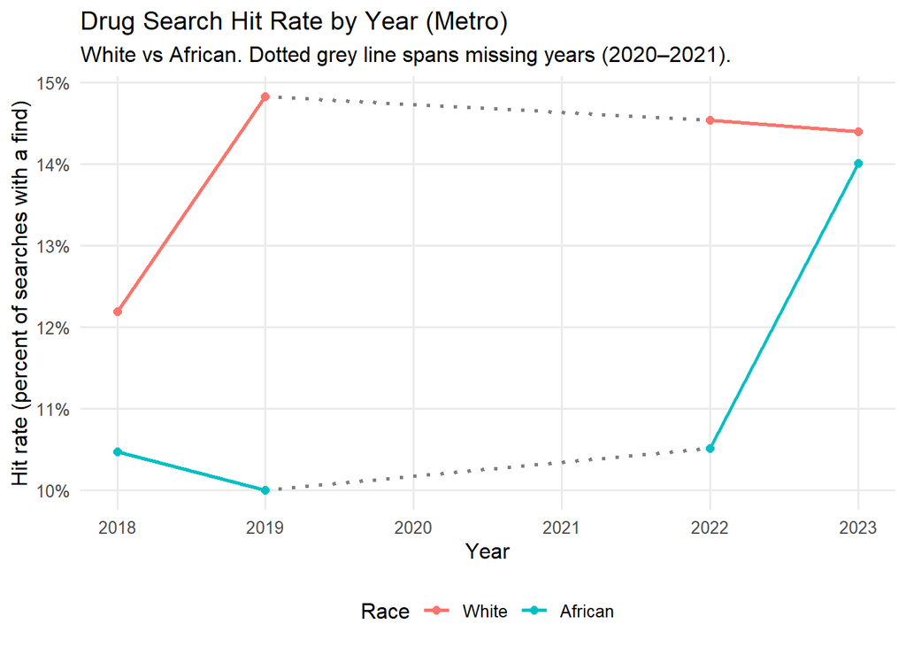

**Table 5 Hit rates by racial appearance and year**

Hit Rate by Year and Race (Metro)

| Year | White (%) | African (%) | Difference (African - White, pp) |
| --- | --- | --- | --- |
| 2018 | 12.19 | 10.48 | -1.72 |
| 2019 | 14.83 | 10.00 | -4.83 |
| 2022 | 14.54 | 10.51 | -4.03 |
| 2023 | 14.40 | 14.01 | -0.39 |

Overall, the descriptive results indicate that **race, year, rank, and division** are significantly associated with variation in hit rates, whereas **gender and age** are not.

Spatial context — particularly division and station — remains the strongest correlating factor, yet the **consistent racial gap** across multiple years suggests the difference cannot be attributed solely to where searches occur.

These findings justify the inclusion of **race, year, rank, and spatial controls** in the multivariate models that follow, which test whether the racial disparity in evidentiary yield persists once contextual factors are held constant.

# 4 Statistical modelling

## 4.1 Model A — Fixed-Effects Logistic Regression (Station × Year)

While descriptive cross-tabulations highlight consistent racial differences in hit rates, they cannot determine whether these disparities reflect **unequal treatment** or simply differences in **where and when** searches occur.

To separate these effects, we estimate a **fixed-effects logistic regression** that isolates racial disparities *within the same police station and year*, holding constant local operational context and temporal variation. This approach allows us to test whether, under comparable conditions, African-appearing individuals were systematically less likely than White-appearing individuals to yield contraband.

However, it is important to recognise that **police-station boundaries are an imperfect proxy for the true spatial context of encounters**. They do not capture variation between specific streets, neighbourhoods, or hotspots within each station’s area. As a result, even with Station × Year controls, some fine-grained geographic differences in policing or community composition may remain unobserved.

### 4.1.1 Sample definition and rationale

**Table 6 Total searches and finds by appearance in model sample**

Hit rates by race among eligible stations (≥10 African searches). Two-sample proportion test: p = 0.111 (N = 5,535 searches).

| Race | Searches | Hits | Hit rate (%) |
| --- | --- | --- | --- |
| White | 4827 | 643 | 13.3% |
| African | 708 | 79 | 11.2% |

### 4.1.2 Model specification

- Dependent variable: whether a search resulted in contraband being found (`Found_yes` = 1).
- Key predictor: perceived racial appearance (*African* vs *White*).
- Covariates: **gender** and **officer rank**.
- Fixed effects: **Station × Year**, absorbing all between-station and between-year variation.
- Standard errors: **clustered by station** to account for repeated observations within sites.

This structure means that all comparisons are made *within the same police station and year*. Each Station × Year combination serves as its own baseline, controlling for unobserved, time-invariant station characteristics (e.g., operational culture, supervision style, local demographics) as well as year-specific shifts in policing intensity.

By conditioning on Station × Year, the model minimises confounding from **where and when** searches occur, yielding a more defensible estimate of the relationship between race and evidentiary yield.

**Table 7 Model A — Fixed-effects logistic regression (Station×Year)**

Fixed-effects logistic regression (Station×Year) — restricted to stations with ≥10 African searches (clustered by Station.uniform; N = 5535 searches).

| Term | Odds Ratio | 95% CI (L) | 95% CI (U) | p-value |
| --- | --- | --- | --- | --- |
| RaceAfrican | 0.720 | 0.543 | 0.953 | 0.022 |
| GenderM | 1.143 | 0.949 | 1.378 | 0.159 |
| Rank_clean::SCONST | 0.948 | 0.751 | 1.197 | 0.656 |
| Rank_clean::SGT | 1.228 | 0.565 | 2.670 | 0.604 |

### 4.1.3 Interpretation

The coefficient on *Race* represents the difference in the odds of a “hit” for African-appearing individuals relative to White-appearing individuals, controlling for gender and officer rank.

Within the same station and year, searches of African-appearing people were **significantly less likely** to result in contraband being found (OR = 0.72, 95% CI [0.54, 0.95], p = 0.022).

This corresponds to roughly a **30 percent lower odds** of a “hit” for African-appearing individuals compared with White-appearing individuals under like-for-like operational contexts.

By contrast, gender and officer rank were not statistically significant predictors of search success, and their inclusion did not materially affect the race coefficient. Searches conducted by Constables, Senior Constables, and Sergeants yielded broadly similar outcomes once station- and year-level variation were held constant.

### 4.1.4 Robustness considerations

- The **Station × Year fixed effects** absorb average differences in search outcomes within each station and year, controlling for unobserved factors such as local crime levels, community composition, or supervisory practices.
- In effect, each station–year combination is compared only to itself, so the estimated racial disparity reflects **average within-station, within-year differences** in evidentiary yield.
- This design mitigates **spatial and structural confounding**, such as deployment patterns or area-level crime intensity, and produces **conservative estimates** of any racial disparity that persists even under like-for-like operational conditions.

Because the model conditions on Station × Year, these results isolate racial differences in evidentiary yield within the same local policing environment and period — supporting the inference that the disparity likely reflects **differential application of search thresholds**, rather than differences in deployment or geography.

## 4.2 Model B — Multilevel Logistic Regression (Random Intercepts for Station)

To complement the fixed-effects analysis, we estimated a **multilevel logistic regression** with **random intercepts for police stations**.

Whereas Model A isolates within-station differences by removing all station-level variation, Model B explicitly models that variation, treating each station’s baseline likelihood of a “hit” as a random effect.

This approach recognises that stations differ systematically in operational practices, local contexts, and levels of policing intensity.

Rather than controlling away this variation, the multilevel model captures it directly, enabling more **city-wide generalisation** while still accounting for the clustering of searches within stations.

The dependent variable again indicates whether contraband was found (*Found_yes = 1*), with predictors for perceived race (*African* vs *White*), gender, and local drug-crime rate.

> **RAND context:**  
> RAND cautioned that raw hit-rate comparisons and simple regressions may confound racial effects with deployment differences.  
> The multilevel design addresses this by modelling both individual-level covariates and station-level heterogeneity, providing a balanced approach that adjusts for structural differences in policing environments without fully removing them (as in the fixed-effects model).

> This allows assessment of whether racial disparities persist **after accounting for typical station-level contexts**, not just within narrow Station×Year comparisons.

### 4.2.1 5.2.2.1 Model summary and robustness checks

**Specification.**  
Model B was estimated using `lme4::glmer` with a logit link:

$$\text{logit}(P(\text{Found})) = \beta_0 + \beta_1(\text{Race}) +
\beta_2(\text{Gender}) + \beta_3(\text{DrugCrimeRate}) +
u_{\text{Station}},$$
where $u_{\text{Station}} \sim N(0, \sigma^2_{\text{Station}})$ represents random intercepts for each police station.

**Sample restrictions.**  
Observations were limited to stations with at least **20 total searches** across all years and to racial appearance categories *African* and *White* to ensure stable group estimates.

**Interpretation.**  
The race coefficient represents the expected difference in the odds of a “hit” for *African* versus *White* individuals, *after accounting for station-level variation, gender, and local drug-crime rate*.

An odds ratio below 1 indicates that, on average across Melbourne, *African-appearing* individuals were less likely to yield contraband even after accounting for local conditions.

**Robustness considerations.**  
- Random intercepts adjust for **average structural heterogeneity** between stations, addressing part of RAND’s critique.  
- Because they do not absorb year-specific shocks or unobserved deployment cycles, some time-varying confounding may remain.  
- Compared with Model A, this model offers broader generalisability but less control over local differences; together, they bracket the plausible range of the racial disparity.

Multilevel logistic regression (random intercepts for Station) — odds of contraband found (Race effect). N = 7,479 searches across 71 stations.

| Term | Odds Ratio | 95% CI (L) | 95% CI (U) | p-value |
| --- | --- | --- | --- | --- |
| African vs White | 0.73 | 0.573 | 0.93 | 0.011 |

Multilevel logistic regression (random intercepts for Station) — all fixed effects. N = 7,479 searches across 71 stations.

| Term | Odds Ratio | 95% CI (L) | 95% CI (U) | p-value |
| --- | --- | --- | --- | --- |
| (Intercept) | 0.146 | 0.122 | 0.176 | <0.001 |
| Race: African vs White | 0.730 | 0.573 | 0.930 | 0.011 |
| Gender: Male vs Female | 1.160 | 0.981 | 1.372 | 0.083 |
| Rank: Senior Constable vs Constable | 1.022 | 0.881 | 1.185 | 0.774 |
| Rank: Sergeant vs Constable | 1.354 | 0.957 | 1.915 | 0.087 |
| Drug crime rate (z) | 0.986 | 0.872 | 1.115 | 0.825 |

### 4.2.2 Model B — Multilevel Logistic Regression (Random Intercepts for Station)

The multilevel model, estimated on **7,479 searches across 71 police stations**, shows that even after accounting for officer rank, gender, and variation between stations, **African-appearing individuals remained significantly less likely to yield contraband** than White-appearing individuals searched under similar conditions.

The odds of a “hit” were approximately **27% lower** for African-appearing individuals (*OR* = 0.73, 95% CI 0.57–0.93, *p* = 0.011).  
This disparity persists after adjusting for station-level context and individual-level covariates.

Gender and rank effects were not statistically significant at the 5 percent level, though searches by **Sergeants** trended toward a higher hit rate (*OR* = 1.35, *p* = 0.087) and **men** were marginally more likely to be found with contraband (*OR* = 1.16, *p* = 0.083).  
Local drug-crime rates showed no meaningful association with search success, suggesting that **station-level operational differences**, rather than area-level crime intensity, account for much of the variation in outcomes.

Together, these findings indicate a **robust racial disparity in evidentiary yield** that is not explained by officer characteristics or local policing environments.

### 4.2.3 Geographic concentration of disparities

Taken together, the two models indicate that racial disparities in search outcomes are **not evenly distributed across metropolitan Melbourne**.

The **multilevel model (Model B)** shows that, on average across all stations, searches of individuals perceived as *African* are significantly less likely to yield contraband than those of *White* individuals—even after adjusting for officer rank, gender, and station-level differences.

# 5 Appendix

Racial appearance vs Found (with totals)

| label | variable | Found No | Found Yes | Total |  |
| --- | --- | --- | --- | --- | --- |
| Racial.appearance.transformed | Aboriginal | 271 (87.7%) | 38 (12.3%) |  | 309 (2.4%) |
|  | African | 669 (88.6%) | 86 (11.4%) | 755 (5.9%) |  |
|  | Asian | 850 (87.0%) | 127 (13.0%) | 977 (7.6%) |  |
|  | Mediterranean/Middle Eastern – Unusable | 1020 (88.1%) | 138 (11.9%) | 1158 (9.0%) |  |
|  | Missing | 2446 (85.5%) | 414 (14.5%) | 2860 (22.3%) |  |
|  | White | 5822 (85.9%) | 957 (14.1%) | 6779 (52.8%) |  |
|  | Total | 11078 (86.3%) | 1760 (13.7%) | 12838 (100.0%) |  |

Overall association test:  
Racial.appearance.transformed — Chi-square (simulated p), p = 0.07837

## 5.1 Hit rates by Division and Station with at least 20 searches

Racial appearance (all groups): count and percentage of searches

| Racial appearance (transformed) | Searches Count | Searches Percent |
| --- | --- | --- |
| White | 6779 | 48.8% |
| Missing | 2860 | 20.6% |
| Mediterranean/Middle Eastern – Unusable | 1158 | 8.3% |
| Asian | 977 | 7.0% |
| African | 755 | 5.4% |
| Aboriginal | 309 | 2.2% |
| South Asian | 300 | 2.2% |
| Pacific Islander | 272 | 2.0% |
| Other | 254 | 1.8% |
| Middle Eastern | 192 | 1.4% |
| South American | 40 | 0.3% |
| Total | 13896 | 100.0% |

*Table X Hit rate disparity at Division level*

Hit-rate disparity by Division (African vs White; only divisions with ≥20 African & ≥0 White searches)

Counts

Hit Rates

Ratio & CI

Significance

Division

African n

White n

African %

White %

Risk ratio

95% CI (L)

95% CI (U)

p-value

sig

NWMR Division 3 (Brimbank, Melton)

70

212

4.3%

14.2%

0.30

-0.17

-0.03

0.026

NWMR Division 2 (Hobsons Bay, Maribyrnong, Wyndham)

139

503

12.2%

17.1%

0.72

-0.11

0.01

0.166

NWMR Division 4 (Hume, Moonee Valley, Merri-bek)

85

598

10.6%

13.7%

0.77

-0.10

0.04

0.428

Eastern Region Division 1 (Boroondara, Manningham, Monash, Whitehorse)

29

507

13.8%

19.3%

0.71

-0.19

0.07

0.460

NWMR Division 5 (Banyule, Darebin, Nillumbik, Whittlesea)

140

1050

11.4%

13.0%

0.88

-0.07

0.04

0.612

NWMR Division 1 (Melbourne, Yarra)

139

1366

10.1%

10.9%

0.92

-0.06

0.04

0.763

SMR Division 3 (Cardinia, Casey, Dandenong)

84

414

14.3%

14.5%

0.99

-0.08

0.08

0.961

SMR Division 1 (Port Phillip, Stonnington)

42

579

11.9%

12.1%

0.98

-0.10

0.10

0.972

*Table X Hit rate disparity at Station level*

Hit-rate disparity by Station (African vs White; Station column = ‘Station.uniform’; only stations with ≥20 African & ≥0 White searches)

Counts

Hit Rates

Ratio & CI

Significance

Station

African n

White n

African %

White %

Risk ratio

95% CI (L)

95% CI (U)

p-value

sig

WERRIBEE

57

103

8.8%

21.4%

0.41

-0.23

-0.02

0.042

CAROLINE SPRINGS

23

21

4.3%

23.8%

0.18

-0.39

0.01

0.060

SUNSHINE

26

66

0.0%

9.1%

0.00

-0.16

-0.02

0.112

FLEMINGTON

23

68

13.0%

29.4%

0.44

-0.34

0.01

0.118

MELBOURNE EAST

28

236

3.6%

13.6%

0.26

-0.18

-0.02

0.131

PAKENHAM

29

132

17.2%

8.3%

2.07

-0.06

0.23

0.147

MELBOURNE NORTH

24

101

25.0%

15.8%

1.58

-0.10

0.28

0.290

HEIDELBERG

33

261

6.1%

11.1%

0.55

-0.14

0.04

0.373

COLLINGWOOD

29

171

6.9%

11.1%

0.62

-0.15

0.06

0.494

RESERVOIR

38

152

15.8%

20.4%

0.77

-0.18

0.09

0.521

CRANBOURNE

26

66

19.2%

24.2%

0.79

-0.23

0.13

0.606

FOOTSCRAY

43

171

11.6%

14.6%

0.80

-0.14

0.08

0.613

BROADMEADOWS

26

114

11.5%

8.8%

1.32

-0.11

0.16

0.661

MELBOURNE WEST

24

272

12.5%

15.4%

0.81

-0.17

0.11

0.700

RICHMOND

21

411

4.8%

6.1%

0.78

-0.11

0.08

0.804

## 5.2 LGAs, crime rate and search intensity

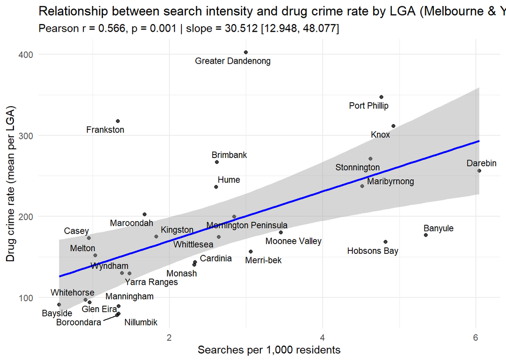

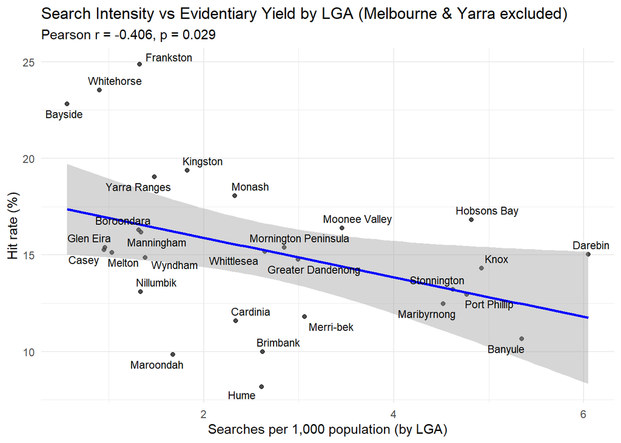

| Local Government Area | Drug crime rate (mean) | Total crime rate (mean) | Records (n) |
| --- | --- | --- | --- |
| Melbourne | 828.16 | 15703.39 | 1201 |
| Yarra | 371.91 | 10571.34 | 1512 |
| Port Phillip | 346.98 | 8801.84 | 486 |
| Greater Dandenong | 402.23 | 8027.25 | 474 |
| Maribyrnong | 237.14 | 7719.5 | 385 |
| Stonnington | 271.29 | 7356.05 | 484 |
| Frankston | 317.64 | 6673.77 | 185 |
| Brimbank | 267.11 | 6554.88 | 510 |
| Darebin | 256.4 | 6394.91 | 898 |
| Hume | 236.36 | 5891.15 | 637 |

[output cut: 21 more lines]